None

# Challenge

**In this notebook's challenge, you will use collected data to develop a model that can *accurately predict* behavior well beyond the scope of the original data.** You will build a model of the tank's height as a function of time in order to predict the height of the tank up to two minutes after it begins draining from a height of $7.4cm$.

In the last challenge, you used *linear extrapolation* to predict a system's behavior beyond the boundaries of what was already measured. Hopefully, you saw the utility of linear extrapolation, but also its limitations. We will try to address some of these in this notebook.

Because you'll be asked to work with the tank data for the assignment in this notebook, we will start by using a dataset for the partial drain of the tank you saw in the last reading. Collected using a different experiment than the dataset provided to you in the last reading, this one was collected using a very accurate laser transducer. Data were collected for the first 70 seconds of the experiment only.

[video not shown]

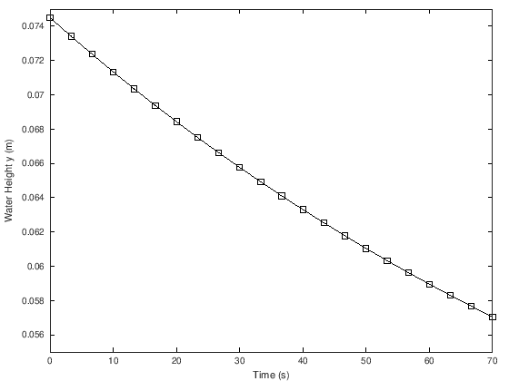

```matlab
data = load('reading5data.txt');
t = data(:,1);
y = data(:,2);
figure
plot(t,y,'ks-')
xlabel('Time (s)')
ylabel('Water Height y (m)')
```

In order to understand *why* extrapolation can be limiting, it is important to understand why using a *straight line* to represent how the system's output evolves over time is often a miss.

Visually, it is fairly easy to see that the plot representing height vs. time in the plot above has "curvature," and is not itself a straight line, so this makes sense intuitively. In the last assignment, extrapolation only worked for very small extensions beyond the scope of the original data, because it seems that as time goes on, *the slope of the plot gets less and less steep,* hence the curvature we see. Because the slope of the tangent line to a function $y(t)$ is its *time derivative*, we can get more insight if we study the time derivative of the data!

To do this, let's look once again at the definition of a derivative, this time a bit more formally.

## Derivatives: Formal Definition

The derivative of y with respect to time, or $\frac{dy}{dt}$, is the *slope* of a line tangent to the y vs. time curve at a particular point. We will use the following formal definition of the derivative of some dependent variable $y$ with respect to some independent variable $t$ at some specific value of $t=a$ :

$$\frac{dy(t)}{dt}|_{t=a} = \lim_{h \rightarrow 0} \frac{y(a) - y(a-h)}{h}$$

You may also have seen a similar, but subtly different definition of the derivative:

$$\frac{dy(t)}{dt}|_{t=a} = \lim_{h \rightarrow 0} \frac{y(a+h)-y(a)}{h}$$

This is essentially equivalent. You could think of this version as approaching the "true" derivative from the right-hand side of the point "a," where the first definition approaches the "true" derivative from the left-hand side of "a." Because they will produce the same results in the situations we'll encounter in this course, we will stick with the first definition.

Importantly, this equation looks like a *slope* or "rise/run" equation. Using the interactive plot below, watch how this slope's accuracy changes as the value of $h$, or the time-difference between the two points used to calculate the derivative, gets larger or smaller. If the cell below shows up blank, click on it and hit Shift+Enter.

[interactive chart not shown]

As you likely noticed, the line representing the "approximate derivative" of the function at some time "a" is most accurate when the value of "h" is smallest. This makes sense, since the *true* derivative is computed in the limit as h goes to zero.

Now, you probably learned many rules for calculating the derivatives of particular functions. For instance, we know that:

$$\frac{d}{dt} (t^2) = 2t$$

and so on. Rules for taking derivatives are [easy to find](https://www.mathsisfun.com/calculus/derivatives-rules.html) in many places!

But if we are dealing with unfamiliar data or system behavior, we may not know what the function $y(t)$ is, **or even what functional form it should take**, so it may be (and often is) necessary to *approximate* the derivative. We often do this using the "finite difference approximation."

## Backward finite difference approximation for a derivative

If the functional form of our data is unknown, making an *exact* derivative calculation impossible, or if approximating the derivative of data we collect is warranted, we can *approximate* the derivative of our output function $y(t)$ at some time $t = t(k)$, or the $k^{th}$ value of time $t$, by the following formula:

$$\left. \frac{d}{dt} y(t)\right|_{t=t(k)} \approx \frac{y(k)-y(k-1)}{t(k)-t(k-1)}$$

This approximation is not very good (see the definition of a derivative) unless the difference between times $t$ in our dataset is very small relative to how the output $y$ changes. This approximation is equivalent to a statement of the *slope* of the data in between times $t=t(k)$ and $t=t(k-1)$, which should be familiar from discussions of *linear interpolation* and *linear extrapolation*.

An example is given below in the MATLAB/Octave language, in which we compute the derivative of some data and then use this derivative to draw a line tangent to the data at a time of our choosing. Think of this like a "static" version of the interactive plot in the cell above.

```
dydt = -6.2791
```

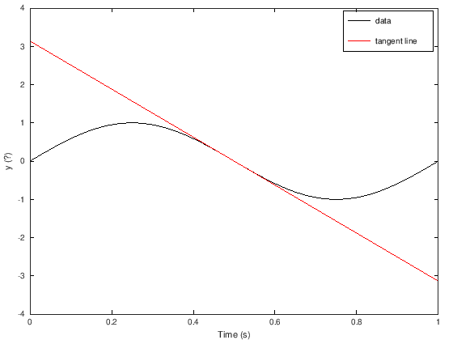

```matlab
%define the time at which we want to compute an approximate derivative
tderiv = 0.5; %you can feel free to try other values!

%define some time data
t = 0:.01:1; %this creates a 'long' array of times 1 row by n columns, starting at 0, with a timestep of .01, ending at 1.
y = sin(2*pi*t);% a sine wave is nice.

%now find out which index in the time array gives us a time closest to "tderiv."
%we will use MATLAB's "find" command for this. use "help find" to learn more.
k = find(t>=tderiv,1,'first');

%now calculate the derivative at our chosen time.
dydt = (y(k)-y(k-1))/(t(k)-t(k-1))

%now let's draw the tangent line in point-slope form
tangentline = dydt*(t-t(k))+y(k);

%now let's plot our data with the derivative on top to see how we did.
figure
plot(t,y,'k',t,tangentline,'r')
xlabel('Time (s)')
ylabel('y (?)')
legend('data','tangent line')
```

As you can see, using the smallest possible value of "h" from the formal definition of the derivative above means computing the slope of "y" using two points that are right next to one another in our dataset. The more "coarse" our data are in time with respect to how the output "y" changes, the worse this approximation will be. This is why it is usually desirable to collect data *as fast as possible*, with as many "points per second" as you possibly can. It makes taking approximate derivatives more accurate.

You can imagine that this might help us understand how the "slope" or derivative of the data at the beginning of this notebook changes. However, this would require us to calculate the approximate derivative of our data *at every point in the data*. This might sound like a task that could get very tedious in code, especially for datasets that might be thousands or *millions* of points long. Thankfully, MATLAB/Octave (as well as most other programming languages) has a structure that we can use to make repetitive calculations simple to implement: The "for loop."